# Case Study 4: Cherry Blossom Race

#### Download all year data into separate files

```r
#write .txt files into folder WomenTxt and call each one by year
wfilenames = paste("./WomenText/", 1999:2012, ".txt", sep = "")
write(womenTables$'1999',wfilenames[1])
write(womenTables$'2000',wfilenames[2])
write(womenTables$'2001',wfilenames[3])
write(womenTables$'2002',wfilenames[4])
write(womenTables$'2003',wfilenames[5])
write(womenTables$'2004',wfilenames[6])
write(womenTables$'2005',wfilenames[7])
write(womenTables$'2006',wfilenames[8])
write(womenTables$'2007',wfilenames[9])
write(womenTables$'2008',wfilenames[10])
write(womenTables$'2009',wfilenames[11])
write(womenTables$'2010',wfilenames[12])
write(womenTables$'2011',wfilenames[13])
write(womenTables$'2012',wfilenames[14])
```

#### Analysis of year 2012 data to get a general understanding of data

```r
womenFiles = lapply(wfilenames, readLines)
names(womenFiles) = 1999:2012

#look at 2012 file to see how to extract variables from the text file
#first 8 lines are not part of the data
els = readLines("./WomenText/2012.txt")
els[1:10]

eqIndex = grep("^===", els)
eqIndex
first3 = substr(els,1,3)
which(first3 == "===")
spacerRow = els[eqIndex]
headerRow = els[eqIndex - 1]
body = els[-(1:eqIndex)]
head(body)
```

1. ''

2. ' Credit Union Cherry Blossom Ten Mile Run'

3. ' Washington, DC Sunday, April 1, 2012'

4. ''

5. ' Female Official Results (Sorted By Net Time)'

6. ''

7. 'Place Div /Tot Num Name Ag Hometown 5 Mile Time Pace S '

8. '===== =========== ====== ====================== == ==================== ======= ======= ===== = '

9. ' 1 1/2781 2 Jelliah Tinega 26 Kenya 26:48 54:02 5:25 ! '

10. ' 2 2/2781 24 Malika Mejdoub 29 Ethiopia 27:09 54:24 5:27 ! '

8

8

1. ' 1 1/2781 2 Jelliah Tinega 26 Kenya 26:48 54:02 5:25 ! '

2. ' 2 2/2781 24 Malika Mejdoub 29 Ethiopia 27:09 54:24 5:27 ! '

3. ' 3 1/2228 22 Yihunlish Delelecha 30 Ethiopia 27:09 54:33 5:28 ! '

4. ' 4 3/2781 14 Agnieszka Ciolek 26 Poland 27:30 54:36 5:28 ! '

5. ' 5 4/2781 4 Claire Hallissey 29 Arlington VA 27:30 54:37 5:28 ! '

6. ' 6 5/2781 6 Stephanie Pezzullo 29 Charlotte NC 27:36 55:16 5:32 ! '

#### Analysis of year 2001 data since this presents a exception scenario

```r
#look at 2012 file to see how to extract variables from the text file
#first 8 lines are not part of the data
els = readLines("./WomenText/2001.txt")
els[1:10]


#els[which(els!="")]
#eqIndex = grep("^[0-9]*", els)
#print("find eqIndex")
#eqIndex

which(str_trim(els)!="")[1]
```

1. ''

2. ' '

3. ' '

4. ' 1 6002 Elana MEYER 34 Rep Of S.africa 52:15 52:16#'

5. ' 2 6004 Lydia GRIGORIEVA 27 Russia 53:12 53:15#'

6. ' 3 6019 Eyerusalem KUMA 20 Ethiopia 53:16 53:19#'

7. ' 4 6007 Milena GLUSAC 25 Usa 53:33 53:34#'

8. ' 5 6012 Olga KOVPOTINA 31 Russia 54:01 54:03#'

9. ' 6 6020 Merima HASHIM 20 Ethiopia 54:29 54:31#'

10. ' 7 6005 Jane OMORO 27 Kenya 55:05 55:08#'

4

```r
#some of them are upper/ lower case in different files and we want them to be the same
headerRow = tolower(headerRow)

ageStart = regexpr('ag', headerRow)
ageStart

age = substr(body, start = ageStart, stop = ageStart +1)
head(age)

blankLocs = gregexpr(" ", spacerRow)
blankLocs

searchLocs = c(0,blankLocs[[1]])
searchLocs

Values = mapply(substr, list(body), start = searchLocs[-length(searchLocs)] + 1, stop = searchLocs[-1] - 1)
length(Values)
```

49

1. '26'

2. '29'

3. '30'

4. '26'

5. '29'

6. '29'

1. 1. 6

   2. 18

   3. 25

   4. 48

   5. 51

   6. 72

   7. 80

   8. 88

   9. 94

   10. 96

1. 0

2. 6

3. 18

4. 25

5. 48

6. 51

7. 72

8. 80

9. 88

10. 94

11. 96

97290

```r
#create function to find column locations
## This function will find the row that divides data from the header records
findColLocs = function(spacerRow) {

  spaceLocs = gregexpr(" ", spacerRow)[[1]]
  rowLength = nchar(spacerRow)

  if (substring(spacerRow, rowLength, rowLength) != " ")
    return( c(0, spaceLocs, rowLength + 1))
  else return(c(0, spaceLocs))
}


## This function will collect column positions of the required columns
## from the header record of the file data
## Since different year data have different header records, regular expression is used
selectCols =
  function(colNames, headerRow, searchLocs)
  {
    sapply(colNames,
           function(name, headerRow, searchLocs)
           {
             startPos = regexpr(name, headerRow)[[1]]
             if (startPos == -1)
               return( c(NA, NA) )

             index = sum(startPos >= searchLocs)
             c(searchLocs[index] + 1, searchLocs[index + 1] - 1)
           },
           headerRow = headerRow, searchLocs = searchLocs )
  }
```

```r
locs2012 <- findColLocs(spacerRow)
length(2012)
length(locs2012)
locs2012

ageLoc = selectCols("ag", headerRow, searchLocs)
ages = mapply(substr, list(body), start = ageLoc[1,], stop = ageLoc[2,])
summary(as.numeric(ages))



shortColNames = c("name", "home", "age", "gun", "net", "time")
locCols = selectCols(shortColNames, headerRow, searchLocs)
Values = mapply(substr, list(body), start = locCols[1,], stop = locCols[2,])
class(Values)

colnames(Values) = shortColNames
head(Values)
tail(Values)
```

1

8

1. 0

2. 6

3. 12

4. 34

5. 37

6. 56

7. 64

8. 72

```
   Min. 1st Qu.  Median    Mean 3rd Qu.    Max.    NA's
   0.00   28.00   33.00   34.81   41.00   83.00       1
```

'matrix'

| name | home | age | gun | net | time |
| --- | --- | --- | --- | --- | --- |
| Lydia GRIGORIEVA | Russia | NA | NA | 53:12 | NA |
| Eyerusalem KUMA | Ethiopia | NA | NA | 53:16 | NA |
| Milena GLUSAC | Usa | NA | NA | 53:33 | NA |
| Olga KOVPOTINA | Russia | NA | NA | 54:01 | NA |
| Merima HASHIM | Ethiopia | NA | NA | 54:29 | NA |
| Jane OMORO | Kenya | NA | NA | 55:05 | NA |

|  | name | home | age | gun | net | time |
| --- | --- | --- | --- | --- | --- | --- |
| [2967,] | Joanna LANZIROTTI | Woodbridge VA | NA | NA | 2:28:53 | NA |
| [2968,] | Stephanie DANNEMILLER | Arlington VA | NA | NA | 2:18:34 | NA |
| [2969,] | Alicia HOSMER | Bethesda MD | NA | NA | 2:30:52 | NA |
| [2970,] | Kathy OBERT | Alexandria VA | NA | NA | 2:35:17 | NA |
| [2971,] | Tonya MCCLARY | Fort Washington MD | NA | NA | 2:41:01 | NA |
| [2972,] | F OPEN guideline * | er USATF Age-Group | NA | NA | guideli | NA |

```r
locs2001 <- findColLocs(spacerRow)
locs2001
els = readLines("./WomenText/2001.txt")

length(2001)
length(locs2001)
eqIndex = which(str_trim(els)!="")[1]
varNames =c("name", "home", "ag", "gun","net", "time")
    # Extract the two key rows and the data
    spacerRow = "===== ===== ===================== == ================== ======= ======="
    headerRow = tolower("PLACE NUM   NAME                  AG HOMETOWN           NET     GUN")
print(headerRow)
blankLocs = gregexpr(" ", spacerRow)
print("blankLocs")
blankLocs

searchLocs = c(0,blankLocs[[1]])
print("searchLocs")
searchLocs
body = els[ -(1 : eqIndex) ]

ageLoc = selectCols("ag", headerRow, searchLocs)
print("ageLoc")
print(ageLoc)
ages = mapply(substr, list(body), start = ageLoc[1,], stop = ageLoc[2,])
summary(as.numeric(ages))

shortColNames = c("name", "home", "age", "gun", "net", "time")
locCols = selectCols(shortColNames, headerRow, searchLocs)
print(locCols)
Values = mapply(substr, list(body), start = locCols[1,], stop = locCols[2,])
class(Values)

colnames(Values) = shortColNames
head(Values)
tail(Values)
```

1. 0

2. 6

3. 12

4. 34

5. 37

6. 56

7. 64

8. 72

1

8

```
[1] "place num   name                  ag hometown           net     gun"
[1] "blankLocs"
```

1. 1. 6

   2. 12

   3. 34

   4. 37

   5. 56

   6. 64

```
[1] "searchLocs"
```

1. 0

2. 6

3. 12

4. 34

5. 37

6. 56

7. 64

```
[1] "ageLoc"
     ag
[1,] 35
[2,] 36
```

```
   Min. 1st Qu.  Median    Mean 3rd Qu.    Max.    NA's
   0.00   28.00   33.00   34.81   41.00   83.00       1
```

```
     name home age gun net time
[1,]   13   38  NA  65  57   NA
[2,]   33   55  NA  NA  63   NA
```

'matrix'

| name | home | age | gun | net | time |
| --- | --- | --- | --- | --- | --- |
| Lydia GRIGORIEVA | Russia | NA | NA | 53:12 | NA |
| Eyerusalem KUMA | Ethiopia | NA | NA | 53:16 | NA |
| Milena GLUSAC | Usa | NA | NA | 53:33 | NA |
| Olga KOVPOTINA | Russia | NA | NA | 54:01 | NA |
| Merima HASHIM | Ethiopia | NA | NA | 54:29 | NA |
| Jane OMORO | Kenya | NA | NA | 55:05 | NA |

|  | name | home | age | gun | net | time |
| --- | --- | --- | --- | --- | --- | --- |
| [2967,] | Joanna LANZIROTTI | Woodbridge VA | NA | NA | 2:28:53 | NA |
| [2968,] | Stephanie DANNEMILLER | Arlington VA | NA | NA | 2:18:34 | NA |
| [2969,] | Alicia HOSMER | Bethesda MD | NA | NA | 2:30:52 | NA |
| [2970,] | Kathy OBERT | Alexandria VA | NA | NA | 2:35:17 | NA |
| [2971,] | Tonya MCCLARY | Fort Washington MD | NA | NA | 2:41:01 | NA |
| [2972,] | F OPEN guideline * | er USATF Age-Group | NA | NA | guideli | NA |

```r
#create function that does above - extract relevant values
# Year 2001 data does not have header record , it has been identified
# by checking if the file has a row that does not start with "==="
extractVariables =
  function(file)
  {
    ##I was trying to parse by the first row since there are no headers and then add that row back to the body
    ##with the body= call being altered
    if (length(grep("^===", file)) == 0) {
      eqIndex = which(str_trim(file)!="")[1]
      varNames =c("name", "home", "ag", "gun","net", "time")
    # Extract the two key rows and the data
    spacerRow = "===== ===== ===================== == ================== ======= ======="
    headerRow = tolower("PLACE NUM   NAME                  AG HOMETOWN           NET     GUN")
    body = file[ -(1 : eqIndex-1) ]
    }

    else {
    # Find the index of the row with =s
    eqIndex = grep("^===", file)
    varNames =c("name", "home", "ag", "gun","net", "time")
    # Extract the two key rows and the data
    spacerRow = file[eqIndex]
    headerRow = tolower(file[ eqIndex - 1 ])
    body = file[ -(1 : eqIndex) ]

  }

      # Obtain the starting and ending positions of variables
    searchLocs = findColLocs(spacerRow)

    locCols = selectCols(varNames, headerRow, searchLocs)

    Values = mapply(substr, list(body), start = locCols[1, ],
                    stop = locCols[2, ])

    colnames(Values) = c("name", "home", "ag", "gun","net", "time")


    invisible(Values)


  }
```

```r
womenResMat = lapply(womenFiles, extractVariables)
```

```r
womenResMat[[3]][1:5,]
```

| name | home | ag | gun | net | time |
| --- | --- | --- | --- | --- | --- |
| Elana MEYER | Rep Of S.africa | 34 | 52:16 | 52:15 | NA |
| Lydia GRIGORIEVA | Russia | 27 | 53:15 | 53:12 | NA |
| Eyerusalem KUMA | Ethiopia | 20 | 53:19 | 53:16 | NA |
| Milena GLUSAC | Usa | 25 | 53:34 | 53:33 | NA |
| Olga KOVPOTINA | Russia | 31 | 54:03 | 54:01 | NA |

```r
length(womenResMat)

sapply(womenResMat, nrow)
```

14

**1999**

2356

**2000**

2167

**2001**

2973

**2002**

3335

**2003**

3544

**2004**

3899

**2005**

4334

**2006**

5437

**2007**

5692

**2008**

6397

**2009**

8325

**2010**

8855

**2011**

9030

**2012**

9729

Back to Top

### Data Cleaning and Reformatting Variables

```r
age = as.numeric(womenResMat[['2012']][ , 'ag'])

tail(age)

age = sapply(womenResMat,function(x) as.numeric(x[ , 'ag']))
```

1. 39

2. 40

3. 31

4. 55

5. 40

6. 38

**null device:** 1

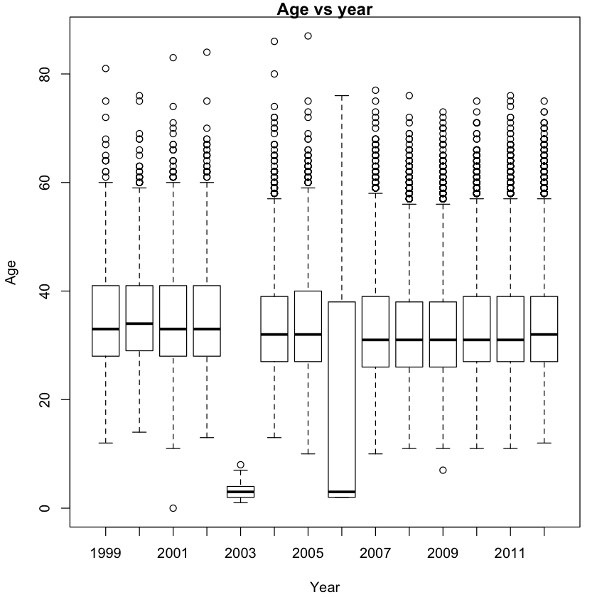

```r
#pdf("CB_BoxplotAgeByYr.pdf", width = 8, height = 5)
oldPar = par(mar = c(4.1, 4.1, 1, 1))

boxplot(age, ylab = "Age", xlab = "Year", main = "Age vs year")

par(oldPar)
dev.off()
```

From above Box Plot of Age by Year , it was observed that the year 2003 and 2006 had lot of yound runners. Lets observe this data

```r
summary(age[["2006"]])
head(womenFiles[["2003"]])
head(womenResMat[["2003"]])
```

```
   Min. 1st Qu.  Median    Mean 3rd Qu.    Max.    NA's
   2.00    2.00    3.00   18.38   38.00   76.00       3
```

1. ''

2. 'Place Div /Tot Num Name Ag Hometown Gun Tim Net Tim '

3. '===== ========= ===== ============================= == =================== ======= ======= '

4. ' 1 1/2510 6014 Olga Romanova 22 RUS 53:43# 53:42 '

5. ' 2 2/2510 6004 Asha Gigi 30 ETH 53:49# 53:49 '

6. ' 3 3/2510 6003 Sylvia Mosqueda 36 Los Angeles CA 53:58# 53:57 '

| name | home | ag | gun | net | time |
| --- | --- | --- | --- | --- | --- |
| Olga Romanova | RUS | 2 | 53:4 | 53:4 | NA |
| Asha Gigi | ETH | 3 | 53:4 | 53:4 | NA |
| Sylvia Mosqueda | Los Angeles CA | 3 | 53:5 | 53:5 | NA |
| Jackline Torori | KEN | 2 | 55:0 | 54:5 | NA |
| Renata Paradowska | POL | 3 | 55:2 | 55:2 | NA |
| Hellen Kimaiyo-Kipkoske | KEN | 3 | 56:1 | 56:1 | NA |

It is observed that for the year 2003 and 2006, only the tenth position of age was picked up , hence returning smaller values. selectCols function was modified to increase the length of the field by 1. Since it is blank, it was expected to have no issue

```r
## This function will collect column positions of the required columns
## from the header record of the file data
## Since different year data have different header records, regular expression is used
selectCols =
  function(colNames, headerRow, searchLocs)
  {
    sapply(colNames,
           function(name, headerRow, searchLocs)
           {
             startPos = regexpr(name, headerRow)[[1]]
             if (startPos == -1)
               return( c(NA, NA) )

             index = sum(startPos >= searchLocs)
             c(searchLocs[index] + 1, searchLocs[index + 1] )
           },
           headerRow = headerRow, searchLocs = searchLocs )
  }
```

```r
womenResMat = lapply(womenFiles, extractVariables)
age = sapply(womenResMat,function(x) as.numeric(x[ , 'ag']))
```

```r
sapply(age,function(x) sum(is.na(x)))
```

**1999**

4

**2000**

1

**2001**

1

**2002**

5

**2003**

2

**2004**

0

**2005**

9

**2006**

3

**2007**

4

**2008**

0

**2009**

4

**2010**

2

**2011**

0

**2012**

0

From the above analysis, we can see that many of the years data have age value as NA. Although these do not form a high percentage we can look for a pattern , if it can be avoided.

**null device:** 1

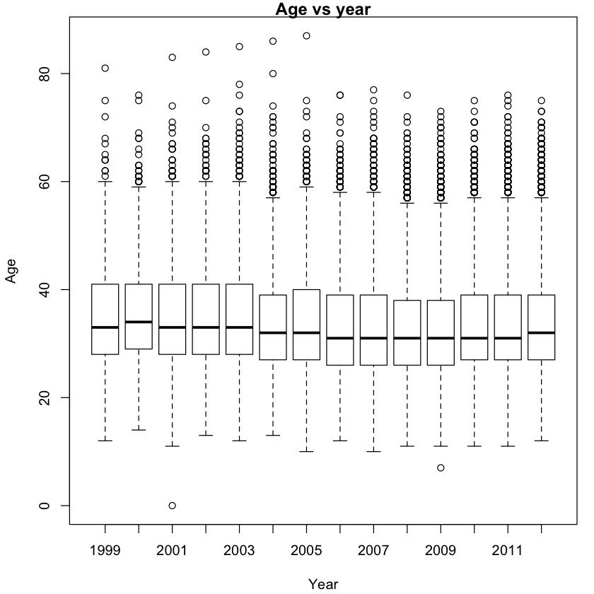

```r
#pdf("CB_BoxplotAgeByYr.pdf", width = 8, height = 5)
oldPar = par(mar = c(4.1, 4.1, 1, 1))

boxplot(age, ylab = "Age", xlab = "Year", main = "Age vs year")

par(oldPar)
dev.off()
```

Box plot of age does not show any alarming age values. Lower quartile seems to be around 27-28 yrs and upper quartile around 41 yrs. There is 1 value that is entered as 0 yrs for the year 2001, but this could be an actual value. And since these are not many it is not concerning.

Back to Age Variable Observations

```r
#womenFiles[[1999]][which(womenFiles[[1999]])]
#womenFiles[["2005"]][1:10]

age2005=age[["2005"]]
naindex2005=which(is.na(age2005))
womenResMat[["2005"]][naindex2005,]
```

| name | home | ag | gun | net | time |
| --- | --- | --- | --- | --- | --- |
| Ashley Griffin | Washington DC |  | 1:15:21 | 1:15:04 | NA |
| Lindsay Vogtsberger | Arlington VA |  | 1:15:43 | 1:08:49 | NA |
| Angelica Jimenez | Washington DC |  | 1:28:35 | 1:21:25 | NA |
| Runner Xxxii | Rockville MD |  | 1:35:43 | 1:27:18 | NA |
| Michelle Hinman |  |  | 1:44:16 | 1:39:13 | NA |
| Xandra Brandon | Washington DC |  | 1:44:40 | 1:39:01 | NA |
| Michelle Merola | Washington DC |  | 1:52:03 | 1:45:15 | NA |
| Nancy Samko | Coraopolis PA |  | 2:03:53 | 1:57:36 | NA |
|  |  |  |  |  | NA |

```r
age2002=age[["2002"]]
naindex2002=which(is.na(age2002))
womenResMat[["2002"]][naindex2002,]
```

| name | home | ag | gun | net | time |
| --- | --- | --- | --- | --- | --- |
| Unknown RUNNER | Washington DC |  | 1:19:45 | 1:18:59 | NA |
| Melissa AKEY | Washington DC |  | 1:34:43 | 1:34:12 | NA |
| Yvonne BONNER | Alexandria VA |  | 1:44:34 | 1:42:08 | NA |
| Unnamed Athlete | Unknown | XX | 2:10:45 | 2:04:55 | NA |
| TF OPEN guideline * | der USATF Age-Group | Un | ne | guideli | NA |

```r
grep("^TF OPEN guideline*",womenResMat[["2002"]])
```

3335

```r
womenResMat[["2002"]][3335,]
```

**name**

'TF OPEN guideline *'

**home**

'der USATF Age-Group'

**ag**

' Un'

**gun**

'ne'

**net**

' guideli'

**time**

NA

```r
#Modify extractVariables function to remove rows that are footnotes
extractVariables =
  function(file)
  {
    ##I was trying to parse by the first row since there are no headers and then add that row back to the body
    ##with the body= call being altered
    if (length(grep("^===", file)) == 0) {
      eqIndex = which(str_trim(file)!="")[1]
      varNames =c("name", "home", "ag", "gun","net", "time")
    # Extract the two key rows and the data
    spacerRow = "===== ===== ===================== == ================== ======= ======="
    headerRow = tolower("PLACE NUM   NAME                  AG HOMETOWN           NET     GUN")
    body = file[ -(1 : eqIndex-1) ]
    }

    else {
    # Find the index of the row with =s
    eqIndex = grep("^===", file)
    varNames =c("name", "home", "ag", "gun","net", "time")
    # Extract the two key rows and the data
    spacerRow = file[eqIndex]
    headerRow = tolower(file[ eqIndex - 1 ])
    body = file[ -(1 : eqIndex) ]

  }

    # Remove footnotes and blank rows
      footnotes = grep("^[[:blank:]]*(\\*|\\#)", body)
      if ( length(footnotes) > 0 ) body = body[ -footnotes ]
      blanks = grep("^[[:blank:]]*$", body)
      if (length(blanks) > 0 ) body = body[ -blanks ]

      footer1 = grep("^TF OPEN guideline*",body)
      if (length(footer1) > 0 ) body = body[ -footer1 ]

      footer2 = grep("^[[#|*]]*",body)
      if (length(footer2) > 0 ) body = body[ -footer2 ]
      # Obtain the starting and ending positions of variables
    searchLocs = findColLocs(spacerRow)

    locCols = selectCols(varNames, headerRow, searchLocs)

    Values = mapply(substr, list(body), start = locCols[1, ],
                    stop = locCols[2, ])

    colnames(Values) = c("name", "home", "ag", "gun",
                         "net", "time")


    invisible(Values)


  }
```

```r
womenResMat = lapply(womenFiles, extractVariables)
age = sapply(womenResMat,function(x) as.numeric(x[ , 'ag']))
sapply(age,function(x) sum(is.na(x)))
```

**1999**

4

**2000**

0

**2001**

0

**2002**

4

**2003**

0

**2004**

0

**2005**

8

**2006**

1

**2007**

2

**2008**

0

**2009**

2

**2010**

0

**2011**

0

**2012**

0

**null device:** 1

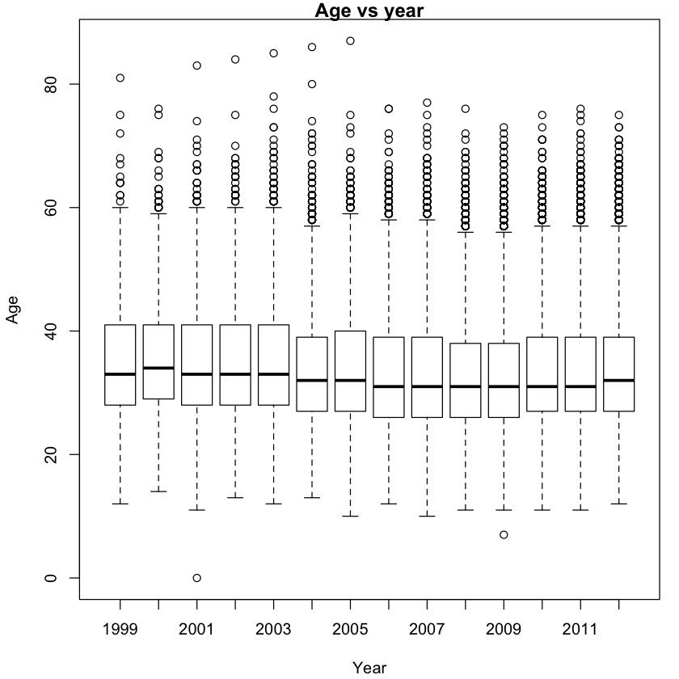

```r
age = sapply(womenResMat,function(x) as.numeric(x[ , 'ag']))

oldPar = par(mar = c(4.1, 4.1, 1, 1))

boxplot(age, ylab = "Age", xlab = "Year", main = "Age vs year")

par(oldPar)
dev.off()
```

```r
age1999=age[["1999"]]
naindex1999=which(is.na(age1999))
womenResMat[["1999"]][naindex1999,]
```

| name | home | ag | gun | net | time |
| --- | --- | --- | --- | --- | --- |
| Lidiya Grigoryeva | Russia |  | NA | NA | 53:40 |
| Gladys Asiba | Kenya |  | NA | NA | 54:50 |
| Connie Buckwalter | Lancaster PA |  | NA | NA | 59:36 |
| Ann Reid | Bethesda MD |  | NA | NA | 1:53:03 |

After removing foot notes and blanks we see therea re still a few null values for age. As was seen above for 2005 data and 1999 data , there are actual null age values and so , so it is decided to leave them as is and impute them later based on the use case.

Back To Time Variable Observations

#### Creation of time variable

```r
charTime = womenResMat[['2012']][, 'time']
head(charTime, 5)

tail(charTime, 5)

timePieces = strsplit(charTime, ":")

timePieces[[1]]

tail(timePieces, 1)

timePieces = sapply(timePieces, as.numeric)

runTime = sapply(timePieces,
                 function(x) {
                   if (length(x) == 2) x[1] + x[2]/60
                   else 60*x[1] + x[2] + x[3]/60
                 })

print("summary of runTime")
summary(runTime)

convertTime = function(time) {
  timePieces = strsplit(time, ":")
  timePieces = sapply(timePieces, as.numeric)
  sapply(timePieces, function(x) {
                      if (length(x) == 2) x[1] + x[2]/60
                      else 60*x[1] + x[2] + x[3]/60
                      })
}
```

1. ' 54:02 '

2. ' 54:24 '

3. ' 54:33 '

4. ' 54:36 '

5. ' 54:37 '

1. '2:33:11 '

2. '2:36:03 '

3. '2:36:45 '

4. '2:36:54 '

5. '2:50:58 '

1. ' 54'

2. '02 '

1. 1. '2'

   2. '50'

   3. '58 '

```
[1] "summary of runTime"
```

```
   Min. 1st Qu.  Median    Mean 3rd Qu.    Max.
  54.03   89.08   98.03   99.02  107.90  170.97
```

```r
createDF =
function(Res, year, sex)
{
       # Determine which time to use
  useTime = if( !is.na(Res[1, 'net']) )
              Res[ , 'net']
            else if( !is.na(Res[1, 'gun']) )
               Res[ , 'gun']
            else
               Res[ , 'time']

  runTime = convertTime(useTime)

  Results = data.frame(year = rep(year, nrow(Res)),
                       sex = rep(sex, nrow(Res)),
                       name = Res[ , 'name'],
                       home = Res[ , 'home'],
                       age = as.numeric(Res[, 'ag']),
                       runTime = runTime,
                       stringsAsFactors = FALSE)
  invisible(Results)
}

womenDF = mapply(createDF, womenResMat, year = 1999:2012,
               sex = rep("W", 14), SIMPLIFY = FALSE)

warnings()[ c(1:2, 49:50) ]
```

[output not shown]

[output cut: 5792 more lines]

[output not shown]

```r
sapply(womenDF, function(x) sum(is.na(x$runTime)))
```

**1999**

0

**2000**

0

**2001**

0

**2002**

0

**2003**

0

**2004**

0

**2005**

0

**2006**

5431

**2007**

192

**2008**

0

**2009**

115

**2010**

107

**2011**

0

**2012**

0

From above analysis, there are few years where the time field is having NAs. On looking at data from those years, it was seen that there are gun or net times available . From the headers in the files, it gun time was considered as official time, so to fetch time value, preference was given in the order of **'gun','net','time'**

```r
## Final CreateDF function that takes care of above issues related
## different time variables available for different years data
createDF = function(Res, year, sex)
{
  # Determine which time to use
  if ( !is.na(Res[1, 'gun']) ) useTime = Res[ , 'gun']
  else if ( !is.na(Res[1, 'net']) ) useTime = Res[ , 'net']
  else useTime = Res[ , 'time']

  # Remove # and * and blanks from time
  useTime = gsub("[#\\*[:blank:]]", "", useTime)
  runTime = convertTime(useTime[ useTime != "" ])

  # Drop rows with no time
  Res = Res[ useTime != "", ]

  Results = data.frame(year = rep(year, nrow(Res)),
                       sex = rep(sex, nrow(Res)),
                       name = Res[ , 'name'], home = Res[ , 'home'],
                       age = as.numeric(Res[, 'ag']),
                       runTime = runTime,
                       stringsAsFactors = FALSE)
  invisible(Results)
}
```

```r
womenDF = mapply(createDF, womenResMat, year = 1999:2012,
               sex = rep("W", 14), SIMPLIFY = FALSE)
```

```r
sapply(womenDF, function(x) sum(is.na(x$runTime)))
```

**1999**

0

**2000**

0

**2001**

0

**2002**

0

**2003**

0

**2004**

0

**2005**

0

**2006**

0

**2007**

0

**2008**

0

**2009**

0

**2010**

0

**2011**

0

**2012**

0

Above analysis show that NAs from time field have been resolved from our solution and all year data have the runTime

**null device:** 1

1. 75971

2. 6

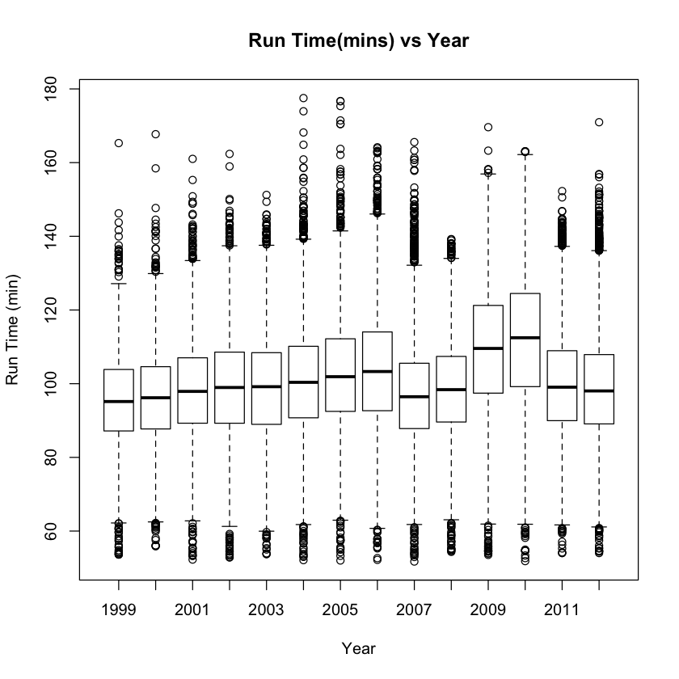

```r
#pdf("CB_BoxplotTimeByYr.pdf", width = 8, height = 5)
boxplot(sapply(womenDF, function(x) x$runTime),
        xlab = "Year", ylab = "Run Time (min)",main="Run Time(mins) vs Year")
dev.off()

cbwomen = do.call(rbind, womenDF)
save(cbwomen, file = "cbwomen.rda")

dim(cbwomen)
```

```r
head(womenDF[["1999"]])
```

| year | sex | name | home | age | runTime |
| --- | --- | --- | --- | --- | --- |
| 1999 | W | Jane Omoro | Kenya | 26 | 53.61667 |
| 1999 | W | Jane Ngotho | Kenya | 29 | 53.63333 |
| 1999 | W | Lidiya Grigoryeva | Russia | NA | 53.66667 |
| 1999 | W | Eunice Sagero | Kenya | 20 | 53.91667 |
| 1999 | W | Alla Zhilyayeva | Russia | 29 | 54.13333 |
| 1999 | W | Teresa Wanjiku | Kenya | 24 | 54.16667 |

```r
runTime = sapply(womenDF,function(x) as.numeric(x[ , 'runTime']))
```

```r
summary(runTime[["2005"]])
```

```
   Min. 1st Qu.  Median    Mean 3rd Qu.    Max.
  52.02   92.48  101.90  102.59  112.18  176.72
```

```r
summary(runTime[["2010"]])
```

```
   Min. 1st Qu.  Median    Mean 3rd Qu.    Max.
  51.85   99.20  112.47  111.84  124.48  163.08
```

```r
summary(runTime[["2004"]])
```

```
   Min. 1st Qu.  Median    Mean 3rd Qu.    Max.
  52.12   90.74  100.37  100.97  110.15  177.52
```

```r
class(womenDF[["1999"]])
```

'data.frame'

```r
class(cbwomen)
```

'data.frame'

```r
dim(cbwomen)
```

1. 75971

2. 6

```r
str(cbwomen)
```

```
'data.frame':	75971 obs. of  6 variables:
 $ year   : int  1999 1999 1999 1999 1999 1999 1999 1999 1999 1999 ...
 $ sex    : chr  "W" "W" "W" "W" ...
 $ name   : chr  "Jane Omoro            " "Jane Ngotho           " "Lidiya Grigoryeva     " "Eunice Sagero         " ...
 $ home   : chr  "Kenya              " "Kenya              " "Russia             " "Kenya              " ...
 $ age    : num  26 29 NA 20 29 24 38 NA 27 30 ...
 $ runTime: num  53.6 53.6 53.7 53.9 54.1 ...
```